# Credit_risk_analysis

## Credit_Risk_Analysis

#### Updating and Importing Libraries

```python
!pip install imblearn
```

```python
import pandas as pd
import numpy as np
import matplotlib.pyplot as plt
import seaborn as sns

import statsmodels
```

```python
## to supress any Pandas warning

pd.set_option('mode.chained_assignment', None)
```

```python
from sklearn.preprocessing import MinMaxScaler, LabelEncoder, OneHotEncoder
```

```python
from sklearn.linear_model import LogisticRegression
from sklearn import metrics
from sklearn.metrics import confusion_matrix, accuracy_score, classification_report, f1_score
from sklearn.neighbors import KNeighborsClassifier
from sklearn.ensemble import RandomForestClassifier
from sklearn.model_selection import GridSearchCV
```

```python
from sklearn.model_selection import train_test_split
```

```python
from sklearn.tree import DecisionTreeClassifier
```

```python
!pip install xgboost
```

```python
from xgboost import XGBClassifier
```

```python
!pip install catboost
```

```python
from catboost import CatBoostClassifier
```

```python
!pip install lightgbm
```

```python
import lightgbm as lgb
from lightgbm import LGBMClassifier
from sklearn.metrics import mean_squared_error
```

```python
from sklearn.metrics import roc_auc_score

import pandas.core.algorithms as algos
import scipy.stats.stats as stats
import traceback
import string
```

```python
!pip install scorecardpy
```

```python
import scorecardpy as sc
```

```python
!pip install mlxtend --break-system-packages
```

```python
import mlxtend
```

```python
# Show every column without cutting off data

pd.set_option('display.max_columns', None)
```

```python
# Set a specific maximum column width for text values

pd.set_option('display.max_colwidth', None)
```

#### Uploading Dataset

```python
train = pd.read_csv('train.csv')
train.head()
```

|  | customer_id | name | age | gender | owns_car | owns_house | no_of_children | net_yearly_income | no_of_days_employed | occupation_type | total_family_members | migrant_worker | yearly_debt_payments | credit_limit | credit_limit_used(%) | credit_score | prev_defaults | default_in_last_6months | credit_card_default |
| --- | --- | --- | --- | --- | --- | --- | --- | --- | --- | --- | --- | --- | --- | --- | --- | --- | --- | --- | --- |
| 0 | CST_115179 | ita Bose | 46 | F | N | Y | 0.0 | 107934.04 | 612.0 | Unknown | 1.0 | 1.0 | 33070.28 | 18690.93 | 73 | 544.0 | 2 | 1 | 1 |
| 1 | CST_121920 | Alper Jonathan | 29 | M | N | Y | 0.0 | 109862.62 | 2771.0 | Laborers | 2.0 | 0.0 | 15329.53 | 37745.19 | 52 | 857.0 | 0 | 0 | 0 |
| 2 | CST_109330 | Umesh Desai | 37 | M | N | Y | 0.0 | 230153.17 | 204.0 | Laborers | 2.0 | 0.0 | 48416.60 | 41598.36 | 43 | 650.0 | 0 | 0 | 0 |
| 3 | CST_128288 | Rie | 39 | F | N | Y | 0.0 | 122325.82 | 11941.0 | Core staff | 2.0 | 0.0 | 22574.36 | 32627.76 | 20 | 754.0 | 0 | 0 | 0 |
| 4 | CST_151355 | McCool | 46 | M | Y | Y | 0.0 | 387286.00 | 1459.0 | Core staff | 1.0 | 0.0 | 38282.95 | 52950.64 | 75 | 927.0 | 0 | 0 | 0 |

```python
train.shape
```

```
(45528, 19)
```

```python
train["credit_card_default"].value_counts(normalize=True)
```

```
credit_card_default
0    0.918797
1    0.081203
Name: proportion, dtype: float64
```

```python
# reshaping(downsizing) the dateset

df = train.sample(n = 30000, random_state = 42, replace = False)
df
```

|  | customer_id | name | age | gender | owns_car | owns_house | no_of_children | net_yearly_income | no_of_days_employed | occupation_type | total_family_members | migrant_worker | yearly_debt_payments | credit_limit | credit_limit_used(%) | credit_score | prev_defaults | default_in_last_6months | credit_card_default |
| --- | --- | --- | --- | --- | --- | --- | --- | --- | --- | --- | --- | --- | --- | --- | --- | --- | --- | --- | --- |
| 34126 | CST_163708 | Wachtel | 50 | F | N | Y | 0.0 | 269502.14 | 4181.0 | Unknown | 1.0 | 0.0 | 17440.44 | 36017.45 | 23 | 807.0 | 0 | 0 | 0 |
| 44609 | CST_131305 | Deepa | 29 | F | N | Y | 0.0 | 115795.25 | 365250.0 | Unknown | 2.0 | 0.0 | 28962.21 | 21781.38 | 60 | 858.0 | 0 | 0 | 0 |
| 44264 | CST_131350 | Jason | 39 | F | N | Y | 0.0 | 113477.67 | 365241.0 | Unknown | 2.0 | 0.0 | 27463.96 | 27485.15 | 81 | 667.0 | 0 | 0 | 1 |
| 33556 | CST_106655 | Gilbert Kreijger | 35 | F | Y | Y | 1.0 | 215555.19 | 1882.0 | Managers | 3.0 | 0.0 | 47863.75 | 25054.25 | 32 | 690.0 | 0 | 0 | 0 |
| 28050 | CST_154013 | Slater | 53 | M | Y | Y | 0.0 | 185082.22 | 365244.0 | Unknown | 2.0 | 0.0 | 47185.73 | 65186.23 | 65 | 721.0 | 0 | 0 | 0 |
| ... | ... | ... | ... | ... | ... | ... | ... | ... | ... | ... | ... | ... | ... | ... | ... | ... | ... | ... | ... |
| 37523 | CST_113336 | Leika Kihara | 26 | F | N | Y | 0.0 | 95125.83 | 365244.0 | Unknown | 1.0 | 0.0 | 18408.08 | 26632.82 | 2 | 790.0 | 0 | 0 | 0 |
| 36228 | CST_151817 | Dixon | 31 | F | N | N | 0.0 | 119277.91 | 891.0 | Laborers | 2.0 | 0.0 | 18243.68 | 16150.12 | 18 | 791.0 | 0 | 0 | 0 |
| 32772 | CST_107659 | P.J. Huffstutter | 50 | F | N | N | 0.0 | 214846.93 | 1740.0 | Sales staff | 2.0 | 0.0 | 16482.42 | 27253.76 | 16 | 709.0 | 0 | 0 | 0 |
| 9762 | CST_141352 | an | 25 | M | N | Y | 0.0 | 175005.61 | 653.0 | Laborers | 2.0 | 0.0 | 19366.06 | 35727.99 | 9 | 691.0 | 0 | 0 | 0 |
| 33325 | CST_129867 | Hyunjoo | 50 | F | N | N | 0.0 | 139512.15 | 939.0 | Core staff | 1.0 | 1.0 | 17139.86 | 23630.38 | 49 | 791.0 | 0 | 0 | 0 |

30000 rows × 19 columns

### Exploratory Data Analysis

```python
df.shape
```

```
(30000, 19)
```

```python
df.info()
```

```
<class 'pandas.core.frame.DataFrame'>
Index: 30000 entries, 34126 to 33325
Data columns (total 19 columns):
 #   Column                   Non-Null Count  Dtype
---  ------                   --------------  -----
 0   customer_id              30000 non-null  object
 1   name                     30000 non-null  object
 2   age                      30000 non-null  int64
 3   gender                   30000 non-null  object
 4   owns_car                 29631 non-null  object
 5   owns_house               30000 non-null  object
 6   no_of_children           29498 non-null  float64
 7   net_yearly_income        30000 non-null  float64
 8   no_of_days_employed      29685 non-null  float64
 9   occupation_type          30000 non-null  object
 10  total_family_members     29944 non-null  float64
 11  migrant_worker           29947 non-null  float64
 12  yearly_debt_payments     29938 non-null  float64
 13  credit_limit             30000 non-null  float64
 14  credit_limit_used(%)     30000 non-null  int64
 15  credit_score             29994 non-null  float64
 16  prev_defaults            30000 non-null  int64
 17  default_in_last_6months  30000 non-null  int64
 18  credit_card_default      30000 non-null  int64
dtypes: float64(8), int64(5), object(6)
memory usage: 4.6+ MB
```

```python
cat_col=[col for col in df.columns if df[col].dtypes == 'object']
cat_col
```

```
['customer_id', 'name', 'gender', 'owns_car', 'owns_house', 'occupation_type']
```

```python
num_col=[col for col in df.columns if df[col].dtypes != 'object']
num_col
```

```
['age',
 'no_of_children',
 'net_yearly_income',
 'no_of_days_employed',
 'total_family_members',
 'migrant_worker',
 'yearly_debt_payments',
 'credit_limit',
 'credit_limit_used(%)',
 'credit_score',
 'prev_defaults',
 'default_in_last_6months',
 'credit_card_default']
```

```python
print('No cat_col:', len(cat_col))
print('No num_col:' ,len(num_col))
```

```
No cat_col: 6
No num_col: 13
```

```python
df.duplicated().sum()
```

```
np.int64(0)
```

### Identifying missing values

```python
df.isnull().sum().sort_values(ascending=False)
```

```
no_of_children             502
owns_car                   369
no_of_days_employed        315
yearly_debt_payments        62
total_family_members        56
migrant_worker              53
credit_score                 6
customer_id                  0
default_in_last_6months      0
prev_defaults                0
credit_limit_used(%)         0
credit_limit                 0
occupation_type              0
name                         0
net_yearly_income            0
owns_house                   0
gender                       0
age                          0
credit_card_default          0
dtype: int64
```

```python
df['credit_card_default'].value_counts()
```

```
credit_card_default
0    27537
1     2463
Name: count, dtype: int64
```

```python
df['credit_card_default'].value_counts(normalize=True)
```

```
credit_card_default
0    0.9179
1    0.0821
Name: proportion, dtype: float64
```

After reshaping,the value_count for credit_card_default remains almost the same. 0(non-defaulters) is 91.79% and 1(defaulter) 8.21%

### Handling missing values(using median,mode)

#### Fill NAN for Categorical features

```python
df[cat_col].isnull().sum()
```

```
customer_id          0
name                 0
gender               0
owns_car           369
owns_house           0
occupation_type      0
dtype: int64
```

```python
for i in cat_col:
    print("Column Name:",i)
    print(df[i].value_counts(normalize=True))
    print("\n")
```

```
Column Name: customer_id
customer_id
CST_163708    0.000033
CST_131964    0.000033
CST_162494    0.000033
CST_138114    0.000033
CST_102185    0.000033
                ...
CST_148239    0.000033
CST_130171    0.000033
CST_132131    0.000033
CST_112807    0.000033
CST_129867    0.000033
Name: proportion, Length: 30000, dtype: float64


Column Name: name
name
Jonathan            0.004367
Jonathan Stempel    0.004133
Jessica             0.003600
Sarah               0.003533
David               0.003467
                      ...
Baker Jonathan      0.000033
Joshua Franklin     0.000033
Fathiya Dahrul      0.000033
Becker              0.000033
Olga Dzyubenko      0.000033
Name: proportion, Length: 3514, dtype: float64


Column Name: gender
gender
F      0.657700
M      0.342267
XNA    0.000033
Name: proportion, dtype: float64


```

[output cut: 21 more lines]

```
Drivers                  0.060767
High skill tech staff    0.037567
Accountants              0.031433
Medicine staff           0.028067
Security staff           0.022100
Cooking staff            0.019667
Cleaning staff           0.015000
Private service staff    0.008467
Low-skill Laborers       0.007633
Secretaries              0.004700
Waiters/barmen staff     0.004600
Realty agents            0.002000
HR staff                 0.001700
IT staff                 0.001667
Name: proportion, dtype: float64
```

As there are missing values mostly less than 2%, so, let us impute all missing values with statistical way. FillNA by MODE - categorical variable and FillNA by MEDIAN - numerical variable

#### FillNA by MODE - categorical variable

### Gender

```python
df['gender'].value_counts()
```

```
gender
F      19731
M      10268
XNA        1
Name: count, dtype: int64
```

```python
## Replacing XNA with M

df['gender'] = df['gender'].apply(lambda x: 'M' if x=='XNA' else x)
df['gender'].value_counts()
```

```
gender
F    19731
M    10269
Name: count, dtype: int64
```

#### Owns_Car (cat_col)

```python
df.fillna({'owns_car':df['owns_car'].mode()[0]},inplace=True)
df['owns_car'].value_counts(normalize=True)
```

```
owns_car
N    0.665033
Y    0.334967
Name: proportion, dtype: float64
```

```python
df[cat_col].isnull().sum()
```

```
customer_id        0
name               0
gender             0
owns_car           0
owns_house         0
occupation_type    0
dtype: int64
```

## FillNA by MEDIAN - Numerical Column

```python
df[num_col].isnull().sum().sort_values(ascending=False).head(10)
```

```
no_of_children          502
no_of_days_employed     315
yearly_debt_payments     62
total_family_members     56
migrant_worker           53
credit_score              6
age                       0
net_yearly_income         0
credit_limit              0
credit_limit_used(%)      0
dtype: int64
```

#### no_of_children(num_col)

```python
df.fillna({'no_of_children': df['no_of_children'].mode()[0]}, inplace=True)
int(df['no_of_children'].isna().sum())
```

```
0
```

#### no_of_days_employed (num_col)

```python
# impute 'no_of_days_employed' with median based on 'occupation_type'

occp_days_employed = df.groupby(by='occupation_type')['no_of_days_employed'].median()

for i in occp_days_employed.index:
    df['no_of_days_employed'] = np.where((df['no_of_days_employed'].isna()) & (df['occupation_type'] == i), occp_days_employed[i], df['no_of_days_employed'])

int(df.no_of_days_employed.isna().sum())
```

```
0
```

#### yearly_debt_payments (num_col)

```python
### impute 'yearly_debt_payments' with median based on 'credit_card_default'

yearDebt_credit = df.groupby(by='credit_card_default')['yearly_debt_payments'].median()
for i in yearDebt_credit.index:
    df['yearly_debt_payments'] = np.where((df['yearly_debt_payments'].isna()) & (df['credit_card_default'] == i), yearDebt_credit[i], df['yearly_debt_payments'])

int(df.yearly_debt_payments.isna().sum())
```

```
0
```

#### total_family_members(num_col)

```python
# imputing with mode of the data

df.fillna({'total_family_members': df['total_family_members'].mode()[0]}, inplace=True)

#check null values count
int(df['total_family_members'].isna().sum())
```

```
0
```

#### migrant_worker(num_col)

```python
# imputing with mode of the data
df.fillna({'migrant_worker': df['migrant_worker'].mode()[0]}, inplace=True)

# check null values count
int(df['migrant_worker'].isna().sum())
```

```
0
```

#### credit_score(num_col)

```python
# check medians of credit_score wrt credit_card_default
cred_score = df.groupby(by='credit_card_default')['credit_score'].median()

for i in cred_score.index:
    df['credit_score'] = np.where((df['credit_score'].isna()) & (df['credit_card_default'] == i), cred_score[i], df['credit_score'])

# check for null values in 'credit_score'
int(df['credit_score'].isna().sum())
```

```
0
```

```python
df[num_col].isnull().sum().sort_values(ascending = False)
```

```
age                        0
no_of_children             0
net_yearly_income          0
no_of_days_employed        0
total_family_members       0
migrant_worker             0
yearly_debt_payments       0
credit_limit               0
credit_limit_used(%)       0
credit_score               0
prev_defaults              0
default_in_last_6months    0
credit_card_default        0
dtype: int64
```

```python
# cat and num col

df.isnull().sum()
```

```
customer_id                0
name                       0
age                        0
gender                     0
owns_car                   0
owns_house                 0
no_of_children             0
net_yearly_income          0
no_of_days_employed        0
occupation_type            0
total_family_members       0
migrant_worker             0
yearly_debt_payments       0
credit_limit               0
credit_limit_used(%)       0
credit_score               0
prev_defaults              0
default_in_last_6months    0
credit_card_default        0
dtype: int64
```

## Concentrated EDA

#### (Key features - credit_card_default, age, credit_score, credit limit percentage,occupation,gender)

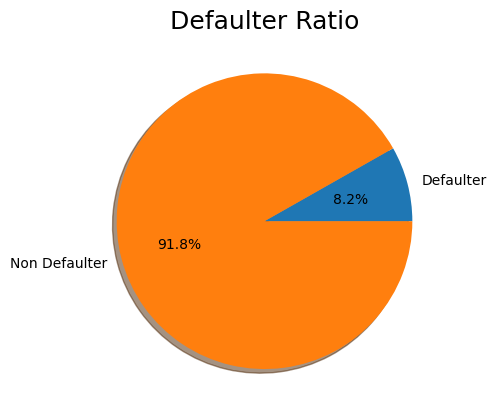

```python
# Ploting Credit_default ratio

total_default_values = df.credit_card_default.value_counts(ascending=True).values

plt.figure()
plt.pie(total_default_values, labels=['Defaulter', 'Non Defaulter'], autopct='%1.1f%%', shadow=True)
plt.title('Defaulter Ratio', fontsize=18)
plt.show()
```

The pie chart shows the distribution of the target variable - 'credit_card_default' Non Defaulter: 91.8% (Majority customers) Defaulter: 8.2% (Very few customers) Reflecting a highly imbalanced dataset.

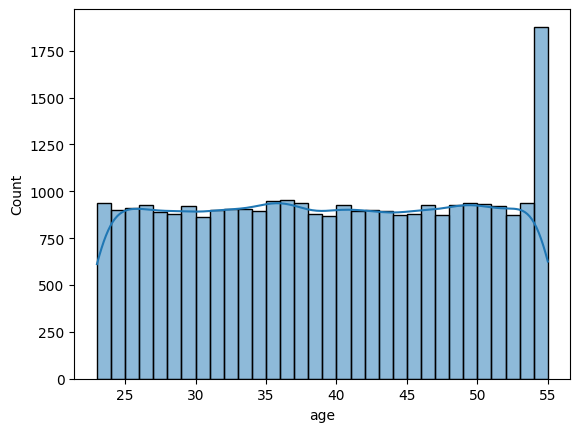

```python
# visualize AGE feature - histplot

plt.figure()
sns.histplot(df['age'], kde=True)
plt.show()
```

-Most ages lie between 23 to 55. -The distribution looks - uniformly spread,no strong skewness,no extreme outliers visible -There is only 1 noticeable spike near 55,as many customers fall in that age hich might be because of age capping during preprocessing, synthetic/generated data rounded values.

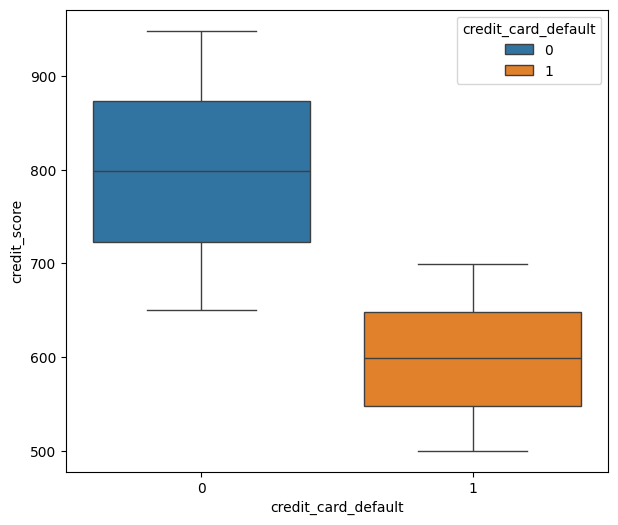

```python
# boxplot of credit_defaulter-credit_score

plt.figure(figsize=[7,6])
sns.boxplot(x=df['credit_card_default'], y=df['credit_score'],hue=df['credit_card_default'])
plt.show()
```

Non-defaulters (class 0) have higher credit scores with a Median credit score ≈ 800 Scores mostly range between 720 – 880 indicating financially reliable customers. Defaulters (Class 1) have lower credit scores with a Median credit score ≈ 600 Scores mostly range between 550 – 650 suggesting a higher financial risk. Therefore Lower credit score → Higher default probability Higher credit score → Lower default probability

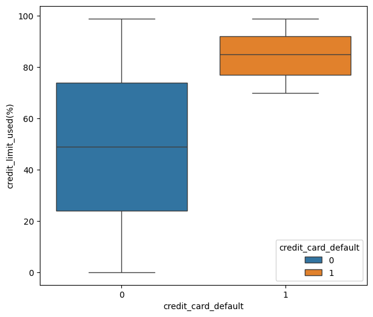

```python
# boxplot of credit_defaulter-credit_limit_utilization

plt.figure(figsize=[7,6])
sns.boxplot(x=df['credit_card_default'],y=df['credit_limit_used(%)'],hue=df['credit_card_default'])
plt.show()
```

-Defaulters box (class 1) is positioned significantly higher on the y-axis compared to Non-defaulters(class 0) indicating that the individuals who default uses higher percentage of their credit limit. -Defaulters show median of 85% which is quite high compared to the median of Non-defaulters 50%. -The box plot reflects a strong positive correlation between credit limit utilization and default risk. -Higher credit limit utilization is one of the key factors for prediciting the credit card defaults.

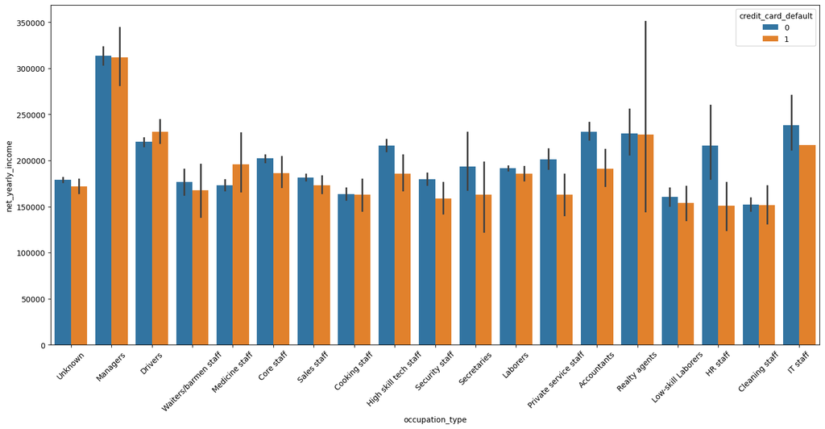

```python
# clustered horizontal barplots for occupation types wrt 'net_yearly_income' and 'credit_default'

plt.figure(figsize=[18,8])
sns.barplot(x=df['occupation_type'], y=df['net_yearly_income'], hue=df['credit_card_default'])
plt.xticks(rotation=45)
plt.show()
```

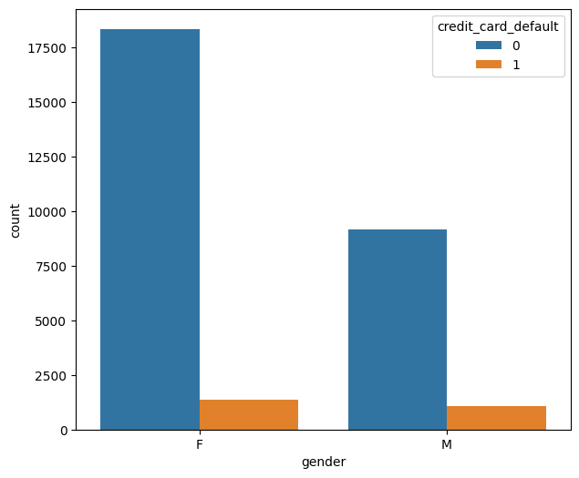

```python
# male or female defaulters

plt.figure(figsize=[7,6])
sns.countplot(x=df['gender'], hue=df['credit_card_default'])
plt.show()
```

The above barchart illustrates a class imbalance comparing the count of individual who are non defaulters (class 0-blue) and defaulters(class 1-orange) across the gender category - male and female.

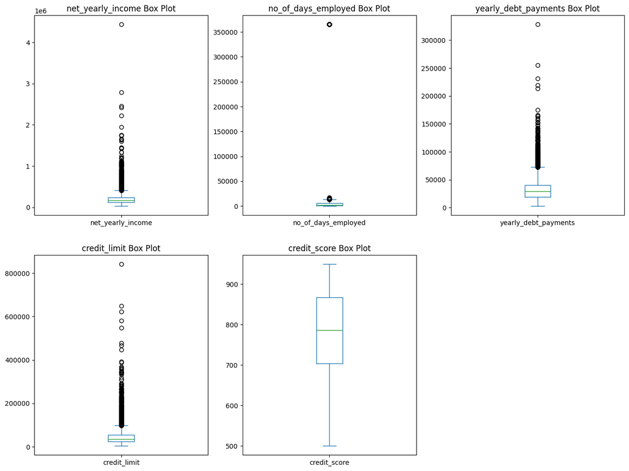

```python
# boxplot of all continuous variables

plt.figure(figsize=[16, 12])
plt.subplot(2,3,1)
df['net_yearly_income'].plot.box()
plt.title('net_yearly_income Box Plot')

plt.subplot(2,3,2)
df['no_of_days_employed'].plot.box()
plt.title('no_of_days_employed Box Plot')

plt.subplot(2,3,3)
df['yearly_debt_payments'].plot.box()
plt.title('yearly_debt_payments Box Plot')

plt.subplot(2,3,4)
df['credit_limit'].plot.box()
plt.title('credit_limit Box Plot')

plt.subplot(2,3,5)
df['credit_score'].plot.box()
plt.title('credit_score Box Plot')
plt.show()
```

## Data Processings

### WOE Binning (grouping categorical variables into discrete categories and replacing them with a calculated WOE score)

```python
selected_vars = ['customer_id', 'name', 'age', 'gender', 'owns_car', 'owns_house',
                  'no_of_children', 'net_yearly_income', 'no_of_days_employed', 'occupation_type',
                  'total_family_members', 'migrant_worker', 'yearly_debt_payments', 'credit_limit',
                  'credit_limit_used(%)', 'credit_score', 'prev_defaults',
                  'default_in_last_6months', 'credit_card_default']
df_woe = df[selected_vars]
```

```python
print(df_woe.dtypes)
```

```
customer_id                 object
name                        object
age                          int64
gender                      object
owns_car                    object
owns_house                  object
no_of_children             float64
net_yearly_income          float64
no_of_days_employed        float64
occupation_type             object
total_family_members       float64
migrant_worker             float64
yearly_debt_payments       float64
credit_limit               float64
credit_limit_used(%)         int64
credit_score               float64
prev_defaults                int64
default_in_last_6months      int64
credit_card_default          int64
dtype: object
```

```python
df_woe = df[selected_vars].copy()
```

```python
# convert categorical columns explicitly

df_woe['occupation_type'] = df_woe['occupation_type'].astype('category')
df_woe['gender'] = df_woe['gender'].astype('category')
```

```python
df = df_woe.drop(columns=['customer_id', 'name'])
```

```python
import warnings
warnings.filterwarnings("ignore", category=FutureWarning)
```

```python
bins = sc.woebin(df, y='credit_card_default')
```

```
[INFO] creating woe binning ...
```

```
Binning on 30000 rows and 17 columns in 00:00:12
```

```python
print(type(bins))
```

```
<class 'dict'>
```

```python
print(len(bins))
```

```
16
```

```python
for var in bins.keys():
    print("\n", "="*50)
    print(var)
    print(bins[var])
```

[output not shown]

[output cut: 178 more lines]

```
1  no_of_children   [1.0,2.0)   5966     0.198867   5412   554  0.092860
2  no_of_children   [2.0,inf)   2990     0.099667   2723   267  0.089298

        woe    bin_iv  total_iv breaks  is_special_values
0 -0.055311  0.002097  0.006803    1.0              False
1  0.134941  0.003831  0.006803    2.0              False
2  0.091910  0.000875  0.006803    inf              False

 ==================================================
prev_defaults
        variable         bin  count  count_distr   good   bad  badprob  woe  \
0  prev_defaults  [-inf,inf)  30000          1.0  27537  2463   0.0821  0.0

   bin_iv  total_iv breaks  is_special_values
0     0.0       0.0    inf              False
```

```
{'migrant_worker': <Figure size 640x480 with 2 Axes>,
 'no_of_days_employed': <Figure size 640x480 with 2 Axes>,
 'owns_house': <Figure size 640x480 with 2 Axes>,
 'gender': <Figure size 640x480 with 2 Axes>,
 'yearly_debt_payments': <Figure size 640x480 with 2 Axes>,
 'net_yearly_income': <Figure size 640x480 with 2 Axes>,
 'credit_limit_used(%)': <Figure size 640x480 with 2 Axes>,
 'credit_limit': <Figure size 640x480 with 2 Axes>,
 'credit_score': <Figure size 640x480 with 2 Axes>,
 'default_in_last_6months': <Figure size 640x480 with 2 Axes>,
 'total_family_members': <Figure size 640x480 with 2 Axes>,
 'age': <Figure size 640x480 with 2 Axes>,
 'occupation_type': <Figure size 640x480 with 2 Axes>,
 'owns_car': <Figure size 640x480 with 2 Axes>,
 'no_of_children': <Figure size 640x480 with 2 Axes>,
 'prev_defaults': <Figure size 640x480 with 2 Axes>}
```

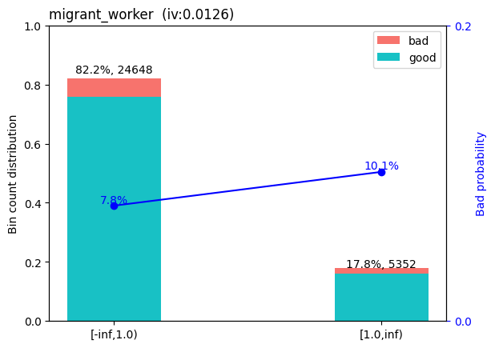

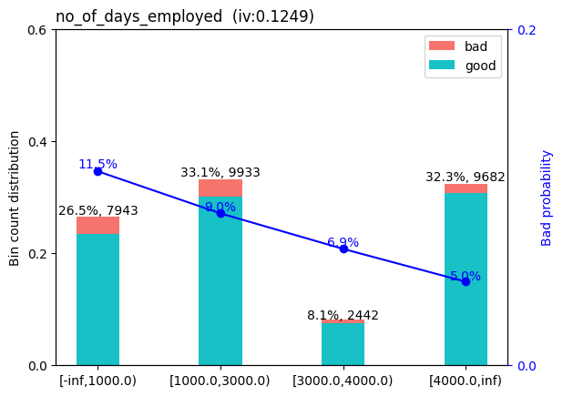

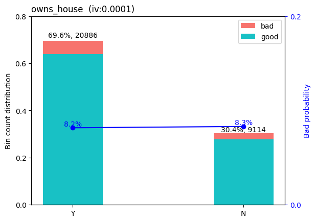

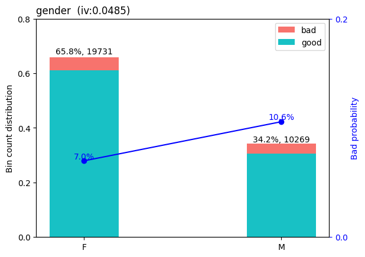

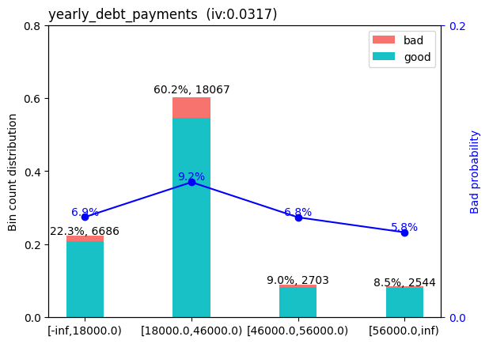

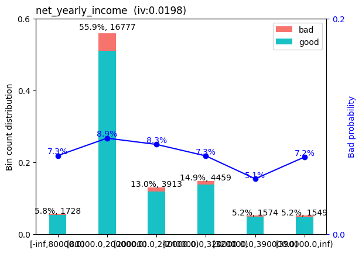

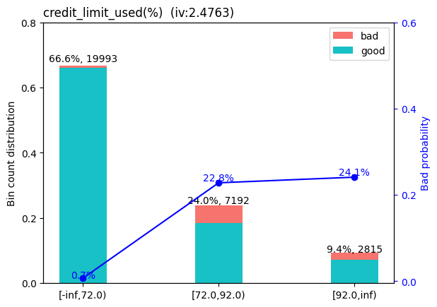

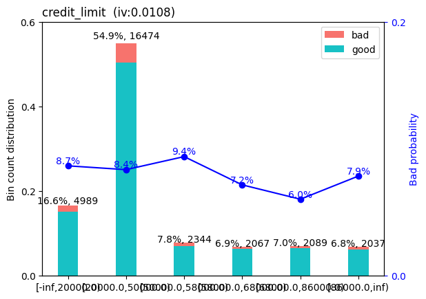

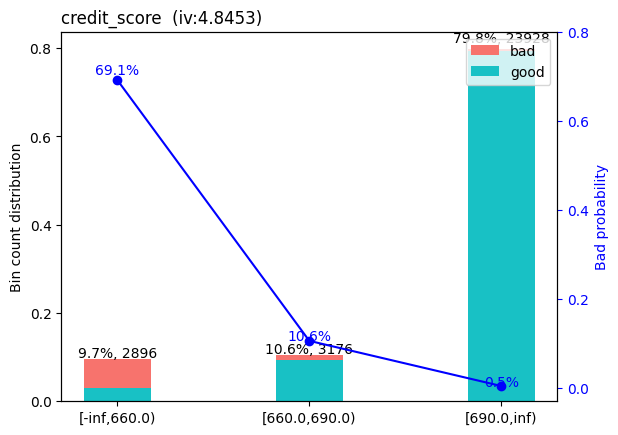

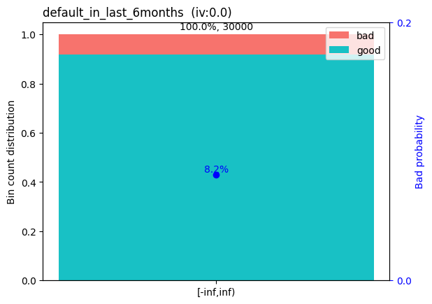

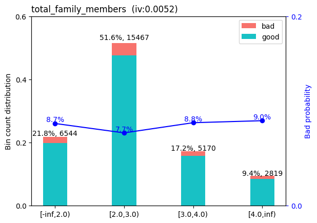

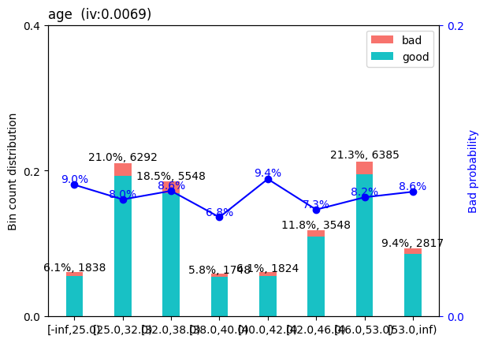

[4 more figures not shown]

```python
# visualizing the Weight of Evidence (WOE) bins created by woebin().

sc.woebin_plot(bins)
```

### Calculating Info_value

```python
import scorecardpy as sc
```

```python
# Calculate IV using credit_card_default as target
iv_df = sc.iv(df,y='credit_card_default')

# Sort IV values from highest to lowest
iv_df = iv_df.sort_values(by='info_value',ascending=False)

print(iv_df)
```

```
                   variable  info_value
15            prev_defaults    6.972746
9   default_in_last_6months    6.712061
8              credit_score    5.166422
6      credit_limit_used(%)    3.079678
1       no_of_days_employed    0.762549
12          occupation_type    0.096320
3                    gender    0.048503
11                      age    0.015057
4      yearly_debt_payments    0.013054
0            migrant_worker    0.012561
14           no_of_children    0.010090
10     total_family_members    0.008589
7              credit_limit    0.004771
13                 owns_car    0.004524
5         net_yearly_income    0.003568
2                owns_house    0.000070
```

```python
low_iv_cols = iv_df.loc[iv_df['info_value'] < 0.02,'variable'].tolist()

print(low_iv_cols)
```

```
['age', 'yearly_debt_payments', 'migrant_worker', 'no_of_children', 'total_family_members', 'credit_limit', 'owns_car', 'net_yearly_income', 'owns_house']
```

```python
# Dropping Variable with low(<0.02)info_value

iv_df = iv_df[iv_df['info_value']>=0.02]
print(iv_df)
```

```
                   variable  info_value
15            prev_defaults    6.972746
9   default_in_last_6months    6.712061
8              credit_score    5.166422
6      credit_limit_used(%)    3.079678
1       no_of_days_employed    0.762549
12          occupation_type    0.096320
3                    gender    0.048503
```

```python
## Transforming the original variables into their corresponding WOE (Weight of Evidence) values using the binning rules stored in bins.

train_woe = sc.woebin_ply(df, bins)
train_woe.head(10)
```

```
[INFO] converting into woe values ...
```

|  | credit_card_default | credit_limit_used(%)_woe | credit_limit_woe | credit_score_woe | migrant_worker_woe | no_of_days_employed_woe | default_in_last_6months_woe | owns_house_woe | gender_woe | age_woe | occupation_type_woe | owns_car_woe | total_family_members_woe | yearly_debt_payments_woe | no_of_children_woe | prev_defaults_woe | net_yearly_income_woe |
| --- | --- | --- | --- | --- | --- | --- | --- | --- | --- | --- | --- | --- | --- | --- | --- | --- | --- |
| 34126 | 0 | -2.518964 | 0.019562 | -2.851316 | -0.055429 | -0.537050 | 0.0 | -0.005566 | -0.175009 | -0.004599 | -0.280276 | 0.046332 | 0.060765 | -0.193449 | -0.055311 | 0.0 | -0.132349 |
| 44609 | 0 | -2.518964 | 0.019562 | -2.851316 | -0.055429 | -0.537050 | 0.0 | -0.005566 | -0.175009 | -0.024660 | -0.280276 | 0.046332 | -0.071457 | 0.130535 | -0.055311 | 0.0 | 0.089601 |
| 44264 | 1 | 1.195478 | 0.019562 | 0.286341 | -0.055429 | -0.537050 | 0.0 | -0.005566 | -0.175009 | -0.202448 | -0.280276 | 0.046332 | -0.071457 | 0.130535 | -0.055311 | 0.0 | 0.089601 |
| 33556 | 0 | -2.518964 | 0.019562 | -2.851316 | -0.055429 | 0.104234 | 0.0 | -0.005566 | -0.175009 | 0.052665 | -0.166805 | -0.097689 | 0.071114 | -0.196714 | 0.134941 | 0.0 | 0.015976 |
| 28050 | 0 | -2.518964 | -0.148197 | -2.851316 | -0.055429 | -0.537050 | 0.0 | -0.005566 | 0.278268 | 0.044954 | -0.280276 | -0.097689 | -0.071457 | -0.196714 | -0.055311 | 0.0 | 0.089601 |
| 4448 | 0 | -2.518964 | 0.058156 | -2.851316 | -0.055429 | 0.104234 | 0.0 | -0.005566 | 0.278268 | -0.202448 | 0.292415 | 0.046332 | 0.097436 | -0.193449 | 0.091910 | 0.0 | 0.089601 |
| 15054 | 0 | -2.518964 | -0.148197 | -2.851316 | -0.055429 | 0.104234 | 0.0 | 0.012659 | 0.278268 | -0.024660 | -0.166805 | 0.046332 | 0.060765 | -0.196714 | -0.055311 | 0.0 | 0.089601 |
| 26095 | 0 | -2.518964 | 0.058156 | -2.851316 | -0.055429 | 0.104234 | 0.0 | -0.005566 | -0.175009 | 0.052665 | -0.166805 | -0.097689 | 0.097436 | 0.130535 | 0.091910 | 0.0 | 0.089601 |
| 2593 | 0 | -2.518964 | 0.058156 | -2.851316 | -0.055429 | 0.376652 | 0.0 | -0.005566 | -0.175009 | 0.052665 | -0.280276 | 0.046332 | -0.071457 | 0.130535 | 0.134941 | 0.0 | 0.089601 |
| 297 | 0 | -2.518964 | 0.146722 | -2.851316 | -0.055429 | -0.537050 | 0.0 | -0.005566 | -0.175009 | -0.024660 | -0.166805 | 0.046332 | 0.071114 | 0.130535 | 0.134941 | 0.0 | 0.015976 |

```python
# dropping text columns that aren't necessary like 'customer_id' and 'name'

old_df = df.copy()

#df.drop(['customer_id', 'name'], axis=1, inplace=True)
df.drop(low_iv_cols, axis=1, inplace=True)
df.head()
```

|  | gender | no_of_days_employed | occupation_type | credit_limit_used(%) | credit_score | prev_defaults | default_in_last_6months | credit_card_default |
| --- | --- | --- | --- | --- | --- | --- | --- | --- |
| 34126 | F | 4181.0 | Unknown | 23 | 807.0 | 0 | 0 | 0 |
| 44609 | F | 365250.0 | Unknown | 60 | 858.0 | 0 | 0 | 0 |
| 44264 | F | 365241.0 | Unknown | 81 | 667.0 | 0 | 0 | 1 |
| 33556 | F | 1882.0 | Managers | 32 | 690.0 | 0 | 0 | 0 |
| 28050 | M | 365244.0 | Unknown | 65 | 721.0 | 0 | 0 | 0 |

```python
df["gender"] = df["gender"].apply(lambda x : 1 if x == "F" else 0)
```

#### Creating dummies of occupation_type

```python
occupation_type_encoded_df = pd.get_dummies(df["occupation_type"], prefix= "occupation")
df = pd.concat([df, occupation_type_encoded_df], axis=1)
df.drop(columns=["occupation_type"], inplace=True)
df.head()
```

|  | gender | no_of_days_employed | credit_limit_used(%) | credit_score | prev_defaults | default_in_last_6months | credit_card_default | occupation_Accountants | occupation_Cleaning staff | occupation_Cooking staff | occupation_Core staff | occupation_Drivers | occupation_HR staff | occupation_High skill tech staff | occupation_IT staff | occupation_Laborers | occupation_Low-skill Laborers | occupation_Managers | occupation_Medicine staff | occupation_Private service staff | occupation_Realty agents | occupation_Sales staff | occupation_Secretaries | occupation_Security staff | occupation_Unknown | occupation_Waiters/barmen staff |
| --- | --- | --- | --- | --- | --- | --- | --- | --- | --- | --- | --- | --- | --- | --- | --- | --- | --- | --- | --- | --- | --- | --- | --- | --- | --- | --- |
| 34126 | 1 | 4181.0 | 23 | 807.0 | 0 | 0 | 0 | False | False | False | False | False | False | False | False | False | False | False | False | False | False | False | False | False | True | False |
| 44609 | 1 | 365250.0 | 60 | 858.0 | 0 | 0 | 0 | False | False | False | False | False | False | False | False | False | False | False | False | False | False | False | False | False | True | False |
| 44264 | 1 | 365241.0 | 81 | 667.0 | 0 | 0 | 1 | False | False | False | False | False | False | False | False | False | False | False | False | False | False | False | False | False | True | False |
| 33556 | 1 | 1882.0 | 32 | 690.0 | 0 | 0 | 0 | False | False | False | False | False | False | False | False | False | False | True | False | False | False | False | False | False | False | False |
| 28050 | 0 | 365244.0 | 65 | 721.0 | 0 | 0 | 0 | False | False | False | False | False | False | False | False | False | False | False | False | False | False | False | False | False | True | False |

### Splitting Data

```python
X = df.drop(['credit_card_default'], axis=1)
y = df['credit_card_default']

X_train, X_test, y_train, y_test = train_test_split(X, y, test_size=0.3, stratify=y, random_state=42)

print("X=",X_train.shape, X_test.shape)
print("y=",y_train.shape, y_test.shape)
```

```
X= (21000, 25) (9000, 25)
y= (21000,) (9000,)
```

```python
X_train.head()
```

|  | gender | no_of_days_employed | credit_limit_used(%) | credit_score | prev_defaults | default_in_last_6months | occupation_Accountants | occupation_Cleaning staff | occupation_Cooking staff | occupation_Core staff | occupation_Drivers | occupation_HR staff | occupation_High skill tech staff | occupation_IT staff | occupation_Laborers | occupation_Low-skill Laborers | occupation_Managers | occupation_Medicine staff | occupation_Private service staff | occupation_Realty agents | occupation_Sales staff | occupation_Secretaries | occupation_Security staff | occupation_Unknown | occupation_Waiters/barmen staff |
| --- | --- | --- | --- | --- | --- | --- | --- | --- | --- | --- | --- | --- | --- | --- | --- | --- | --- | --- | --- | --- | --- | --- | --- | --- | --- |
| 26658 | 1 | 365246.0 | 96 | 922.0 | 0 | 0 | False | False | False | False | False | False | False | False | False | False | False | False | False | False | False | False | False | True | False |
| 5389 | 1 | 1206.0 | 16 | 711.0 | 0 | 0 | False | True | False | False | False | False | False | False | False | False | False | False | False | False | False | False | False | False | False |
| 8704 | 1 | 4040.0 | 18 | 761.0 | 0 | 0 | False | False | False | True | False | False | False | False | False | False | False | False | False | False | False | False | False | False | False |
| 37747 | 0 | 96.0 | 51 | 854.0 | 0 | 0 | False | False | False | False | False | False | False | False | False | False | False | True | False | False | False | False | False | False | False |
| 27346 | 0 | 5326.0 | 92 | 700.0 | 0 | 0 | False | False | False | False | False | False | False | False | True | False | False | False | False | False | False | False | False | False | False |

```python
y_train
```

```
26658    0
5389     0
8704     0
37747    0
27346    0
        ..
34093    0
823      0
32715    0
14006    0
21152    0
Name: credit_card_default, Length: 21000, dtype: int64
```

```python
# WOE data

X_woe = train_woe.drop(['credit_card_default'], axis=1)
y_woe = train_woe['credit_card_default']

X_train_woe, X_test_woe, y_train_woe, y_test_woe = train_test_split(X_woe, y_woe, test_size=0.3, stratify=y_woe, random_state=42)

print("X=",X_train_woe.shape, X_test_woe.shape)
print("y=",y_train_woe.shape, y_test_woe.shape)
```

```
X= (21000, 16) (9000, 16)
y= (21000,) (9000,)
```

```python
X_train_woe.head()
```

|  | credit_limit_used(%)_woe | credit_limit_woe | credit_score_woe | migrant_worker_woe | no_of_days_employed_woe | default_in_last_6months_woe | owns_house_woe | gender_woe | age_woe | occupation_type_woe | owns_car_woe | total_family_members_woe | yearly_debt_payments_woe | no_of_children_woe | prev_defaults_woe | net_yearly_income_woe |
| --- | --- | --- | --- | --- | --- | --- | --- | --- | --- | --- | --- | --- | --- | --- | --- | --- |
| 26658 | 1.268081 | 0.146722 | -2.851316 | -0.055429 | -0.537050 | 0.0 | -0.005566 | -0.175009 | 0.052665 | -0.280276 | 0.046332 | -0.071457 | -0.193449 | -0.055311 | 0.0 | 0.015976 |
| 5389 | -2.518964 | 0.058156 | -2.851316 | 0.226851 | 0.104234 | 0.0 | -0.005566 | -0.175009 | 0.044954 | 0.072676 | 0.046332 | 0.071114 | 0.130535 | 0.134941 | 0.0 | -0.128576 |
| 8704 | -2.518964 | 0.019562 | -2.851316 | -0.055429 | -0.537050 | 0.0 | -0.005566 | -0.175009 | 0.104362 | -0.369523 | 0.046332 | 0.071114 | -0.193449 | 0.134941 | 0.0 | 0.089601 |
| 37747 | -2.518964 | 0.019562 | -2.851316 | -0.055429 | 0.376652 | 0.0 | -0.005566 | 0.278268 | -0.123203 | -0.166805 | -0.097689 | 0.060765 | -0.196714 | -0.055311 | 0.0 | 0.015976 |
| 27346 | 1.268081 | 0.146722 | -2.851316 | -0.055429 | -0.537050 | 0.0 | 0.012659 | 0.278268 | 0.052665 | 0.292415 | 0.046332 | -0.071457 | 0.130535 | -0.055311 | 0.0 | 0.089601 |

```python
y_woe
```

```
34126    0
44609    0
44264    1
33556    0
28050    0
        ..
37523    0
36228    0
32772    0
9762     0
33325    0
Name: credit_card_default, Length: 30000, dtype: int64
```

### Scaling data

```python
# scaling the features to standardize
scaler = MinMaxScaler()

cols = X_train.columns
X_train[cols] = scaler.fit_transform(X_train[cols])
X_test[cols] = scaler.transform(X_test[cols])
```

#### Data Imbalancing Handling

```python
from imblearn.over_sampling import SMOTE
```

```python
# initialize SMOTE method

sm = SMOTE(random_state=42)
X_train,y_train = sm.fit_resample(X_train,y_train)
```

```python
print("Dimension of X_train_sm Shape:", X_train.shape)
print("Dimension of y_train_sm Shape:", y_train.shape)
```

```
Dimension of X_train_sm Shape: (38552, 25)
Dimension of y_train_sm Shape: (38552,)
```

```python
X_train = pd.DataFrame(data=X_train, columns=cols)
print("X_train.shape:",X_train.shape)
y_train = pd.Series(y_train)
print("y_train.shape:",y_train.shape)
X_train.head()
```

```
X_train.shape: (38552, 25)
y_train.shape: (38552,)
```

|  | gender | no_of_days_employed | credit_limit_used(%) | credit_score | prev_defaults | default_in_last_6months | occupation_Accountants | occupation_Cleaning staff | occupation_Cooking staff | occupation_Core staff | occupation_Drivers | occupation_HR staff | occupation_High skill tech staff | occupation_IT staff | occupation_Laborers | occupation_Low-skill Laborers | occupation_Managers | occupation_Medicine staff | occupation_Private service staff | occupation_Realty agents | occupation_Sales staff | occupation_Secretaries | occupation_Security staff | occupation_Unknown | occupation_Waiters/barmen staff |
| --- | --- | --- | --- | --- | --- | --- | --- | --- | --- | --- | --- | --- | --- | --- | --- | --- | --- | --- | --- | --- | --- | --- | --- | --- | --- |
| 0 | 1.0 | 0.999984 | 0.969697 | 0.939866 | 0.0 | 0.0 | 0.0 | 0.0 | 0.0 | 0.0 | 0.0 | 0.0 | 0.0 | 0.0 | 0.0 | 0.0 | 0.0 | 0.0 | 0.0 | 0.0 | 0.0 | 0.0 | 0.0 | 1.0 | 0.0 |
| 1 | 1.0 | 0.003296 | 0.161616 | 0.469933 | 0.0 | 0.0 | 0.0 | 1.0 | 0.0 | 0.0 | 0.0 | 0.0 | 0.0 | 0.0 | 0.0 | 0.0 | 0.0 | 0.0 | 0.0 | 0.0 | 0.0 | 0.0 | 0.0 | 0.0 | 0.0 |
| 2 | 1.0 | 0.011055 | 0.181818 | 0.581292 | 0.0 | 0.0 | 0.0 | 0.0 | 0.0 | 1.0 | 0.0 | 0.0 | 0.0 | 0.0 | 0.0 | 0.0 | 0.0 | 0.0 | 0.0 | 0.0 | 0.0 | 0.0 | 0.0 | 0.0 | 0.0 |
| 3 | 0.0 | 0.000257 | 0.515152 | 0.788419 | 0.0 | 0.0 | 0.0 | 0.0 | 0.0 | 0.0 | 0.0 | 0.0 | 0.0 | 0.0 | 0.0 | 0.0 | 0.0 | 1.0 | 0.0 | 0.0 | 0.0 | 0.0 | 0.0 | 0.0 | 0.0 |
| 4 | 0.0 | 0.014576 | 0.929293 | 0.445434 | 0.0 | 0.0 | 0.0 | 0.0 | 0.0 | 0.0 | 0.0 | 0.0 | 0.0 | 0.0 | 1.0 | 0.0 | 0.0 | 0.0 | 0.0 | 0.0 | 0.0 | 0.0 | 0.0 | 0.0 | 0.0 |

```python
y_train.value_counts(normalize=True)
```

```
credit_card_default
0    0.5
1    0.5
Name: proportion, dtype: float64
```

### Logistic Regression

```python
from statsmodels.discrete.discrete_model import Logit

logit = Logit(y_train, X_train)
logit_fit = logit.fit()
```

```python
# Detailed statistical breakdown of your logistic regression model

logit_fit.summary()
```

Logit Regression Results

| Dep. Variable: | credit_card_default | No. Observations: | 38552 |
| --- | --- | --- | --- |
| Model: | Logit | Df Residuals: | 38527 |
| Method: | MLE | Df Model: | 24 |
| Date: | Tue, 16 Jun 2026 | Pseudo R-squ.: | 0.4984 |
| Time: | 17:39:37 | Log-Likelihood: | -13405. |
| converged: | False | LL-Null: | -26722. |
| Covariance Type: | nonrobust | LLR p-value: | 0.000 |

|  | coef | std err | z | P>\|z\| | [0.025 | 0.975] |
| --- | --- | --- | --- | --- | --- | --- |
| gender | -0.1968 | 0.072 | -2.749 | 0.006 | -0.337 | -0.056 |
| no_of_days_employed | -0.3081 | 0.115 | -2.672 | 0.008 | -0.534 | -0.082 |
| credit_limit_used(%) | 9.2943 | 0.219 | 42.503 | 0.000 | 8.866 | 9.723 |
| credit_score | -26.3145 | 0.615 | -42.753 | 0.000 | -27.521 | -25.108 |
| prev_defaults | 263.2647 | 59.808 | 4.402 | 0.000 | 146.043 | 380.486 |
| default_in_last_6months | -23.0260 | 2.813 | -8.187 | 0.000 | -28.539 | -17.513 |
| occupation_Accountants | 3.8655 | 0.315 | 12.278 | 0.000 | 3.248 | 4.483 |
| occupation_Cleaning staff | 4.3373 | 0.347 | 12.492 | 0.000 | 3.657 | 5.018 |
| occupation_Cooking staff | 4.5636 | 0.331 | 13.781 | 0.000 | 3.915 | 5.213 |
| occupation_Core staff | 4.1199 | 0.286 | 14.407 | 0.000 | 3.559 | 4.680 |
| occupation_Drivers | 4.1163 | 0.283 | 14.557 | 0.000 | 3.562 | 4.671 |
| occupation_HR staff | 1.1363 | 1.221 | 0.930 | 0.352 | -1.258 | 3.530 |
| occupation_High skill tech staff | 2.7927 | 0.322 | 8.664 | 0.000 | 2.161 | 3.424 |
| occupation_IT staff | -15.9695 | 2905.906 | -0.005 | 0.996 | -5711.441 | 5679.502 |
| occupation_Laborers | 3.9471 | 0.271 | 14.541 | 0.000 | 3.415 | 4.479 |
| occupation_Low-skill Laborers | 3.9467 | 0.409 | 9.657 | 0.000 | 3.146 | 4.748 |
| occupation_Managers | 3.5840 | 0.289 | 12.381 | 0.000 | 3.017 | 4.151 |
| occupation_Medicine staff | 3.4782 | 0.332 | 10.482 | 0.000 | 2.828 | 4.129 |
| occupation_Private service staff | 2.4475 | 0.430 | 5.694 | 0.000 | 1.605 | 3.290 |
| occupation_Realty agents | 2.3664 | 0.824 | 2.872 | 0.004 | 0.752 | 3.981 |
| occupation_Sales staff | 3.9178 | 0.280 | 13.999 | 0.000 | 3.369 | 4.466 |
| occupation_Secretaries | 2.2059 | 0.592 | 3.724 | 0.000 | 1.045 | 3.367 |
| occupation_Security staff | 3.1293 | 0.345 | 9.082 | 0.000 | 2.454 | 3.805 |
| occupation_Unknown | 3.5746 | 0.276 | 12.948 | 0.000 | 3.033 | 4.116 |
| occupation_Waiters/barmen staff | 5.0792 | 0.436 | 11.649 | 0.000 | 4.225 | 5.934 |

Possibly complete quasi-separation: A fraction 0.60 of observations can be  
perfectly predicted. This might indicate that there is complete  
quasi-separation. In this case some parameters will not be identified.

```python
lr = LogisticRegression(penalty='l1', C=0.9, solver='saga', n_jobs=-1)
lr.fit(X_train_woe, y_train_woe)
```

```
LogisticRegression(C=0.9, n_jobs=-1, penalty='l1', solver='saga')
```

```python
# predicted proability

train_pred = lr.predict_proba(X_train_woe)[:,1]
test_pred = lr.predict_proba(X_test_woe)[:,1]
```

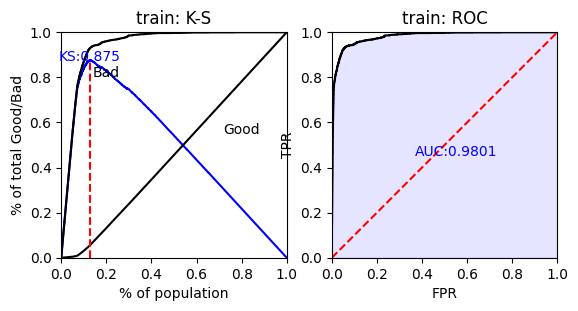

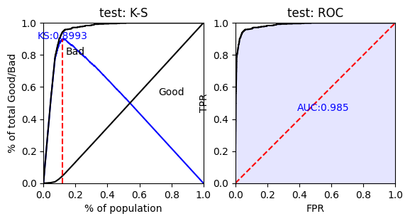

```python
# performance ks & roc ------
train_perf = sc.perf_eva(y_train_woe, train_pred, title = "train")
test_perf = sc.perf_eva(y_test_woe, test_pred, title = "test")
```

```python
# score ------
card = sc.scorecard(bins, lr, X_train_woe.columns)

old_df = old_df.copy()

# credit score
score = sc.scorecard_ply(old_df, card, only_total_score=False, print_step=0, replace_blank_na=True, var_kp = None)
```

```python
score
```

|  | credit_limit_used(%)_points | credit_limit_points | credit_score_points | migrant_worker_points | no_of_days_employed_points | gender_points | age_points | occupation_type_points | owns_car_points | yearly_debt_payments_points | net_yearly_income_points | score |
| --- | --- | --- | --- | --- | --- | --- | --- | --- | --- | --- | --- | --- |
| 34126 | 177.0 | -2.0 | 201.0 | 1.0 | 35.0 | 10.0 | 0.0 | 4.0 | -6.0 | 15.0 | 2.0 | 996.0 |
| 44609 | 177.0 | -2.0 | 201.0 | 1.0 | 35.0 | 10.0 | 1.0 | 4.0 | -6.0 | -10.0 | -1.0 | 969.0 |
| 44264 | -84.0 | -2.0 | -20.0 | 1.0 | 35.0 | 10.0 | 9.0 | 4.0 | -6.0 | -10.0 | -1.0 | 495.0 |
| 33556 | 177.0 | -2.0 | 201.0 | 1.0 | -7.0 | 10.0 | -2.0 | 2.0 | 13.0 | 15.0 | -0.0 | 967.0 |
| 28050 | 177.0 | 12.0 | 201.0 | 1.0 | 35.0 | -16.0 | -2.0 | 4.0 | 13.0 | 15.0 | -1.0 | 998.0 |
| ... | ... | ... | ... | ... | ... | ... | ... | ... | ... | ... | ... | ... |
| 37523 | 177.0 | -2.0 | 201.0 | 1.0 | 35.0 | 10.0 | 1.0 | 4.0 | -6.0 | -10.0 | -1.0 | 969.0 |
| 36228 | 177.0 | -5.0 | 201.0 | 1.0 | -25.0 | 10.0 | 1.0 | -4.0 | -6.0 | -10.0 | -1.0 | 898.0 |
| 32772 | 177.0 | -2.0 | 201.0 | 1.0 | -7.0 | 10.0 | 0.0 | -2.0 | -6.0 | 15.0 | -0.0 | 946.0 |
| 9762 | 177.0 | -2.0 | 201.0 | 1.0 | -25.0 | -16.0 | 1.0 | -4.0 | -6.0 | -10.0 | -1.0 | 875.0 |
| 33325 | 177.0 | -2.0 | 201.0 | -3.0 | -25.0 | 10.0 | 0.0 | 5.0 | -6.0 | 15.0 | -1.0 | 930.0 |

30000 rows × 12 columns

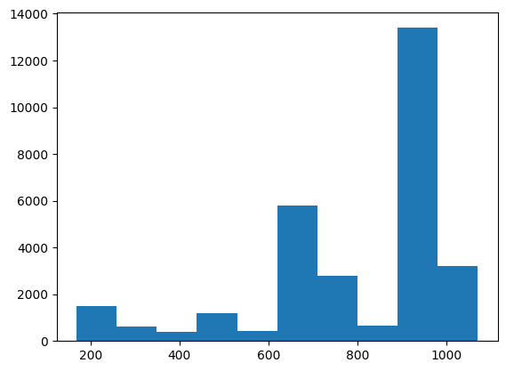

```python
plt.hist(score["score"])
```

- The data is heavily skewed towards the higher end of the scale.There are 2 major clusters - one between 600-750 and another much larger dominant spike around 900s, which typically correlate with lower credit risk. - This suggests that the majority of the individuals in this dataset have high scores, which typically correlates with lower credit risk. - There is a much smaller concentration of data point in the lower range(200 to 500),representing a minority of high-risk entries.

## Evaluation matrix

```python
# evaluation function

def evaluation(model):
    y_train_pred = model.predict(X_train)
    y_test_pred = model.predict(X_test)
    print("="*50)

    print(confusion_matrix(y_train, y_train_pred))
    print(classification_report(y_train, y_train_pred))
    print("Accuracy of TRAIN data:", 100*accuracy_score(y_train, y_train_pred))
    print("F1_Score of TRAIN data:", 100*f1_score(y_train, y_train_pred, average="macro"))
    print("="*50)

    print(confusion_matrix(y_test, y_test_pred))
    print(classification_report(y_test, y_test_pred))
    print("Accuracy of TEST data:", 100*accuracy_score(y_test, y_test_pred))
    print("F1_Score of TEST data:", 100*f1_score(y_test, y_test_pred, average="macro"))
    print("="*50)

    # calculate the RMSE
    rmse = np.sqrt(mean_squared_error(y_test, y_test_pred))
    print("RMSE: ", rmse)

    # calculate ROC AUC
    roc_auc = roc_auc_score(y_test, y_test_pred, average=None)
    print("ROC AUC score: ", roc_auc)
```

```python
y_test
```

```
11858    0
22651    0
38925    0
2917     0
18012    0
        ..
37539    0
17978    1
5227     0
3994     0
8471     0
Name: credit_card_default, Length: 9000, dtype: int64
```

#### Logisitc Regression

```python
# initialize LogisticRegression and fit the model

logreg = LogisticRegression()
logreg.fit(X_train, y_train)
```

```
LogisticRegression()
```

```python
# prediction

evaluation(logreg)
```

```
==================================================
[[18239  1037]
 [  617 18659]]
              precision    recall  f1-score   support

           0       0.97      0.95      0.96     19276
           1       0.95      0.97      0.96     19276

    accuracy                           0.96     38552
   macro avg       0.96      0.96      0.96     38552
weighted avg       0.96      0.96      0.96     38552

Accuracy of TRAIN data: 95.70969080722142
F1_Score of TRAIN data: 95.70918154097276
==================================================
[[7798  463]
 [  19  720]]
              precision    recall  f1-score   support

           0       1.00      0.94      0.97      8261
           1       0.61      0.97      0.75       739

    accuracy                           0.95      9000
   macro avg       0.80      0.96      0.86      9000
weighted avg       0.97      0.95      0.95      9000

Accuracy of TEST data: 94.64444444444445
F1_Score of TEST data: 85.96203549320371
==================================================
RMSE:  0.23142073276946376
ROC AUC score:  0.9591215485188158
```

## Decision Tree

```python
# initialize and fit the model

tree_model = DecisionTreeClassifier()
tree_model.fit(X_train, y_train)
```

```
DecisionTreeClassifier()
```

```python
# prediction

evaluation(tree_model)
```

```
==================================================
[[19276     0]
 [    0 19276]]
              precision    recall  f1-score   support

           0       1.00      1.00      1.00     19276
           1       1.00      1.00      1.00     19276

    accuracy                           1.00     38552
   macro avg       1.00      1.00      1.00     38552
weighted avg       1.00      1.00      1.00     38552

Accuracy of TRAIN data: 100.0
F1_Score of TRAIN data: 100.0
==================================================
[[8050  211]
 [  89  650]]
              precision    recall  f1-score   support

           0       0.99      0.97      0.98      8261
           1       0.75      0.88      0.81       739

    accuracy                           0.97      9000
   macro avg       0.87      0.93      0.90      9000
weighted avg       0.97      0.97      0.97      9000

Accuracy of TEST data: 96.66666666666667
F1_Score of TEST data: 89.71036585365853
==================================================
RMSE:  0.18257418583505536
ROC AUC score:  0.9270126402177667
```

## Random Forest

```python
# initialize and fit the model

regr_rfr = RandomForestClassifier(random_state=42, oob_score=True)
regr_rfr.fit(X_train, y_train)
```

```
RandomForestClassifier(oob_score=True, random_state=42)
```

```python
# prediction

evaluation(regr_rfr)
```

```
==================================================
[[19276     0]
 [    0 19276]]
              precision    recall  f1-score   support

           0       1.00      1.00      1.00     19276
           1       1.00      1.00      1.00     19276

    accuracy                           1.00     38552
   macro avg       1.00      1.00      1.00     38552
weighted avg       1.00      1.00      1.00     38552

Accuracy of TRAIN data: 100.0
F1_Score of TRAIN data: 100.0
==================================================
[[8009  252]
 [  73  666]]
              precision    recall  f1-score   support

           0       0.99      0.97      0.98      8261
           1       0.73      0.90      0.80       739

    accuracy                           0.96      9000
   macro avg       0.86      0.94      0.89      9000
weighted avg       0.97      0.96      0.97      9000

Accuracy of TEST data: 96.38888888888889
F1_Score of TEST data: 89.19881060625838
==================================================
RMSE:  0.19002923751652298
ROC AUC score:  0.9353565402360965
```

## CatBoost

```python
# Initialize and fit the model

reg_catb = CatBoostClassifier(random_seed=42)
reg_catb.fit(X_train, y_train)
```

[output not shown]

[output cut: 946 more lines]

[output not shown]

```
CatBoostClassifier(random_seed=42)
```

```python
# prediction
evaluation(reg_catb)
```

```
==================================================
[[19071   205]
 [   26 19250]]
              precision    recall  f1-score   support

           0       1.00      0.99      0.99     19276
           1       0.99      1.00      0.99     19276

    accuracy                           0.99     38552
   macro avg       0.99      0.99      0.99     38552
weighted avg       0.99      0.99      0.99     38552

Accuracy of TRAIN data: 99.40080929653455
F1_Score of TRAIN data: 99.40079637879083
==================================================
[[8057  204]
 [  74  665]]
              precision    recall  f1-score   support

           0       0.99      0.98      0.98      8261
           1       0.77      0.90      0.83       739

    accuracy                           0.97      9000
   macro avg       0.88      0.94      0.91      9000
weighted avg       0.97      0.97      0.97      9000

Accuracy of TEST data: 96.91111111111111
F1_Score of TEST data: 90.50774677126812
==================================================
RMSE:  0.1757523510195209
ROC AUC score:  0.937585167535671
```

### XGBoost

```python
# Initialize and fit the model

xgb_model = XGBClassifier(random_seed=42)
xgb_model.fit(X_train, y_train)
```

```
XGBClassifier(base_score=None, booster=None, callbacks=None,
              colsample_bylevel=None, colsample_bynode=None,
              colsample_bytree=None, device=None, early_stopping_rounds=None,
              enable_categorical=False, eval_metric=None, feature_types=None,
              feature_weights=None, gamma=None, grow_policy=None,
              importance_type=None, interaction_constraints=None,
              learning_rate=None, max_bin=None, max_cat_threshold=None,
              max_cat_to_onehot=None, max_delta_step=None, max_depth=None,
              max_leaves=None, min_child_weight=None, missing=nan,
              monotone_constraints=None, multi_strategy=None, n_estimators=None,
              n_jobs=None, num_parallel_tree=None, ...)
```

```python
# prediction

evaluation(xgb_model)
```

```
==================================================
[[19044   232]
 [   23 19253]]
              precision    recall  f1-score   support

           0       1.00      0.99      0.99     19276
           1       0.99      1.00      0.99     19276

    accuracy                           0.99     38552
   macro avg       0.99      0.99      0.99     38552
weighted avg       0.99      0.99      0.99     38552

Accuracy of TRAIN data: 99.33855571695372
F1_Score of TRAIN data: 99.33853627657253
==================================================
[[8044  217]
 [  70  669]]
              precision    recall  f1-score   support

           0       0.99      0.97      0.98      8261
           1       0.76      0.91      0.82       739

    accuracy                           0.97      9000
   macro avg       0.87      0.94      0.90      9000
weighted avg       0.97      0.97      0.97      9000

Accuracy of TEST data: 96.81111111111112
F1_Score of TEST data: 90.29289489136818
==================================================
RMSE:  0.17857460314638499
ROC AUC score:  0.9395046977999072
```

```python
xgb_model.feature_importances_
```

```
array([0.00931961, 0.01161044, 0.11123751, 0.62002844, 0.03398515,
       0.02012188, 0.00746186, 0.01355023, 0.00649294, 0.01391891,
       0.01388959, 0.        , 0.02209179, 0.        , 0.01000313,
       0.00386124, 0.0166196 , 0.00754175, 0.01885029, 0.00214677,
       0.01209913, 0.01452901, 0.00553574, 0.01804676, 0.00705822],
      dtype=float32)
```

```python
from xgboost import plot_importance
```

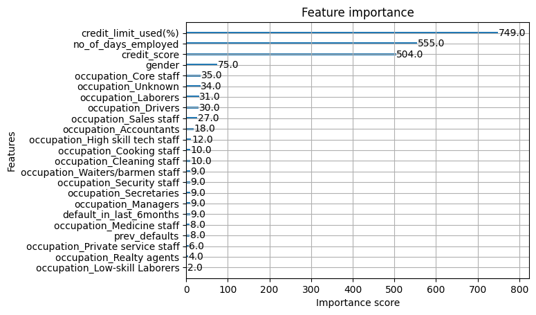

```python
plot_importance(xgb_model)
plt.show()
plt.savefig("Feature importance.png")
```

## LightGBM

```python
# Initialize and fit the model

lgbm_model = LGBMClassifier(random_state=42)
lgbm_model.fit(X_train, y_train)
```

[output not shown]

```
LGBMClassifier(random_state=42)
```

```python
# prediction

evaluation(lgbm_model)
```

```
==================================================
[[19004   272]
 [   46 19230]]
              precision    recall  f1-score   support

           0       1.00      0.99      0.99     19276
           1       0.99      1.00      0.99     19276

    accuracy                           0.99     38552
   macro avg       0.99      0.99      0.99     38552
weighted avg       0.99      0.99      0.99     38552

Accuracy of TRAIN data: 99.17514007055405
F1_Score of TRAIN data: 99.17511172283086
==================================================
[[8048  213]
 [  75  664]]
              precision    recall  f1-score   support

           0       0.99      0.97      0.98      8261
           1       0.76      0.90      0.82       739

    accuracy                           0.97      9000
   macro avg       0.87      0.94      0.90      9000
weighted avg       0.97      0.97      0.97      9000

Accuracy of TEST data: 96.8
F1_Score of TEST data: 90.21020266089108
==================================================
RMSE:  0.17888543819998318
ROC AUC score:  0.9363638493080697
```

## KNN

```python
## Iterating knn model for all values of k from 1-39

error_rate = []

for i in range(1,40):
    knn = KNeighborsClassifier(n_neighbors=i)
    knn.fit(X_train, y_train)
    pred_i = knn.predict(X_test)
    error_rate.append(np.mean(pred_i != y_test))
```

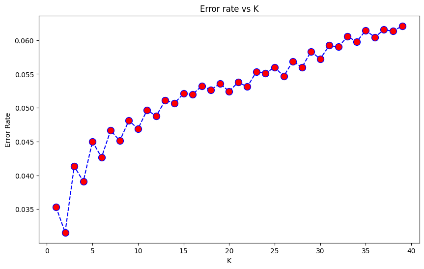

```python
# ploting the error_rate

plt.figure(figsize=[10,6])
plt.plot(range(1,40), error_rate, color='blue', linestyle='dashed',
          marker='o', markerfacecolor='red', markersize=10)
plt.title('Error rate vs K')
plt.xlabel('K')
plt.ylabel('Error Rate')
```

```python
# # building knn and fit the model

knn = KNeighborsClassifier(n_neighbors = 2)
knn.fit(X_train, y_train)
```

```
KNeighborsClassifier(n_neighbors=2)
```

```python
# # Evaluation

evaluation(knn)
```

```
==================================================
[[19276     0]
 [  249 19027]]
              precision    recall  f1-score   support

           0       0.99      1.00      0.99     19276
           1       1.00      0.99      0.99     19276

    accuracy                           0.99     38552
   macro avg       0.99      0.99      0.99     38552
weighted avg       0.99      0.99      0.99     38552

Accuracy of TRAIN data: 99.35411911184893
F1_Score of TRAIN data: 99.35409216702074
==================================================
[[8067  194]
 [  90  649]]
              precision    recall  f1-score   support

           0       0.99      0.98      0.98      8261
           1       0.77      0.88      0.82       739

    accuracy                           0.97      9000
   macro avg       0.88      0.93      0.90      9000
weighted avg       0.97      0.97      0.97      9000

Accuracy of TEST data: 96.84444444444445
F1_Score of TEST data: 90.15911585431118
==================================================
RMSE:  0.1776388345929897
ROC AUC score:  0.9273649813534388
```

Conclusion: - Random Forest, Decision Tree, LightGBM, KNN, CatBoost and XGBoost models performed well with almost the same accuracy of 0.96 However minor difference exsit in F1_Score, precision and recall. - The most significant variables in predicting credit card defaults are credit score, credit limit utilization and number of days employed. - Age of the borrower is not a significant factor in predicting credit card defaults highlighting the importance of considering other variables when analyzing credit risk. - By using machine learning techniques such as XGBoost,Random Forest, Decision Tree, LightGBM, KNN, CatBoost financial institutions can better identify and manage credit risk, thereby reducing their losses due to defaults.